# Gapminder 탐색적 데이터 분석 (EDA) 보고서

Author

세종대학교

Published

June 27, 2026

## 1 개요

본 보고서는 Hans Rosling의 Gapminder 데이터셋에 대한 탐색적 데이터 분석(EDA) 결과를 담고 있습니다. 분석 대상은 1952년부터 2007년까지 5년 간격으로 수집된 **142개국**의 기대수명, 인구, 1인당 GDP 데이터입니다.

**코드 보기**

```python
import pandas as pd
import matplotlib.pyplot as plt
import matplotlib.ticker as mticker
import seaborn as sns
import warnings
warnings.filterwarnings("ignore")

plt.rcParams["figure.dpi"] = 120
plt.rcParams["axes.spines.top"] = False
plt.rcParams["axes.spines.right"] = False

df = pd.read_csv("gapminder_clean.csv")
print(f"데이터 크기: {df.shape[0]}행 × {df.shape[1]}열")
df.head()
```

```
데이터 크기: 1704행 × 8열
```

|  | country | continent | year | lifeexp | pop | gdppercap | iso_alpha | iso_num |
| --- | --- | --- | --- | --- | --- | --- | --- | --- |
| 0 | Afghanistan | Asia | 1952 | 28.80 | 8425333 | 779.45 | AFG | 4 |
| 1 | Afghanistan | Asia | 1957 | 30.33 | 9240934 | 820.85 | AFG | 4 |
| 2 | Afghanistan | Asia | 1962 | 32.00 | 10267083 | 853.10 | AFG | 4 |
| 3 | Afghanistan | Asia | 1967 | 34.02 | 11537966 | 836.20 | AFG | 4 |
| 4 | Afghanistan | Asia | 1972 | 36.09 | 13079460 | 739.98 | AFG | 4 |

## 2 데이터 기본 정보

### 2.1 구조 및 타입

**코드 보기**

```python
df.dtypes.to_frame("타입").T
```

|  | country | continent | year | lifeexp | pop | gdppercap | iso_alpha | iso_num |
| --- | --- | --- | --- | --- | --- | --- | --- | --- |
| 타입 | str | str | int64 | float64 | int64 | float64 | str | int64 |

### 2.2 기초 통계량

수치형 컬럼(기대수명, 인구, 1인당 GDP)의 기초 통계량입니다. 인구와 GDP의 표준편차가 평균 대비 매우 크며, 이는 국가 간 격차가 상당함을 의미합니다.

**코드 보기**

```python
df[["lifeexp", "pop", "gdppercap"]].describe().round(2)
```

|  | lifeexp | pop | gdppercap |
| --- | --- | --- | --- |
| count | 1704.00 | 1.704000e+03 | 1704.00 |
| mean | 59.47 | 2.960121e+07 | 7215.33 |
| std | 12.92 | 1.061579e+08 | 9857.45 |
| min | 23.60 | 6.001100e+04 | 241.17 |
| 25% | 48.20 | 2.793664e+06 | 1202.06 |
| 50% | 60.71 | 7.023596e+06 | 3531.84 |
| 75% | 70.84 | 1.958522e+07 | 9325.46 |
| max | 82.60 | 1.318683e+09 | 113523.13 |

### 2.3 결측치 확인

**코드 보기**

```python
missing = df.isnull().sum().to_frame("결측치 수")
missing["비율(%)"] = (missing["결측치 수"] / len(df) * 100).round(2)
missing
```

|  | 결측치 수 | 비율(%) |
| --- | --- | --- |
| country | 0 | 0.0 |
| continent | 0 | 0.0 |
| year | 0 | 0.0 |
| lifeexp | 0 | 0.0 |
| pop | 0 | 0.0 |
| gdppercap | 0 | 0.0 |
| iso_alpha | 0 | 0.0 |
| iso_num | 0 | 0.0 |

> 결측치가 전혀 없는 완전한 데이터셋입니다.

## 3 변수 분포 분석

### 3.1 기대수명 분포

전체 기대수명의 분포는 약한 이봉(bimodal) 형태를 보입니다. 이는 선진국(고기대수명 그룹)과 개발도상국(저기대수명 그룹)이 혼재하기 때문입니다.

**코드 보기**

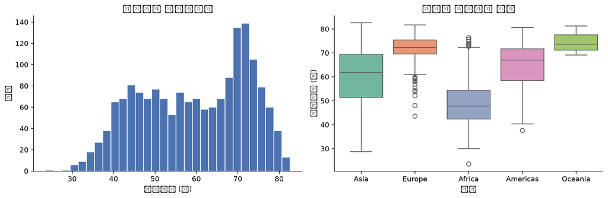

```python
fig, axes = plt.subplots(1, 2, figsize=(12, 4))

axes[0].hist(df["lifeexp"], bins=30, color="#4C72B0", edgecolor="white")
axes[0].set_xlabel("기대수명 (세)")
axes[0].set_ylabel("빈도")
axes[0].set_title("기대수명 히스토그램")

sns.boxplot(data=df, x="continent", y="lifeexp", ax=axes[1], palette="Set2")
axes[1].set_xlabel("대륙")
axes[1].set_ylabel("기대수명 (세)")
axes[1].set_title("대륙별 기대수명 분포")

plt.tight_layout()
plt.show()
```

### 3.2 1인당 GDP 분포

1인당 GDP는 강한 우측 꼬리(right-skewed) 분포를 가집니다. 로그 변환 시 정규분포에 가까워지며, 이후 분석에서 로그 스케일 사용을 권장합니다.

**코드 보기**

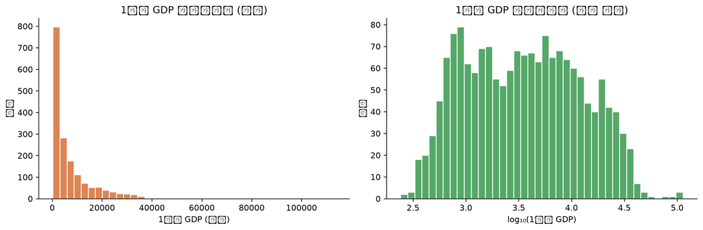

```python
import numpy as np

fig, axes = plt.subplots(1, 2, figsize=(12, 4))

axes[0].hist(df["gdppercap"], bins=40, color="#DD8452", edgecolor="white")
axes[0].set_xlabel("1인당 GDP (달러)")
axes[0].set_ylabel("빈도")
axes[0].set_title("1인당 GDP 히스토그램 (원본)")

axes[1].hist(np.log10(df["gdppercap"]), bins=40, color="#55A868", edgecolor="white")
axes[1].set_xlabel("log₁₀(1인당 GDP)")
axes[1].set_ylabel("빈도")
axes[1].set_title("1인당 GDP 히스토그램 (로그 변환)")

plt.tight_layout()
plt.show()
```

### 3.3 인구 분포

인구 역시 극단적인 우편향 분포를 보입니다. 중국과 인도가 상위를 차지하며 전체 평균을 크게 끌어올립니다.

**코드 보기**

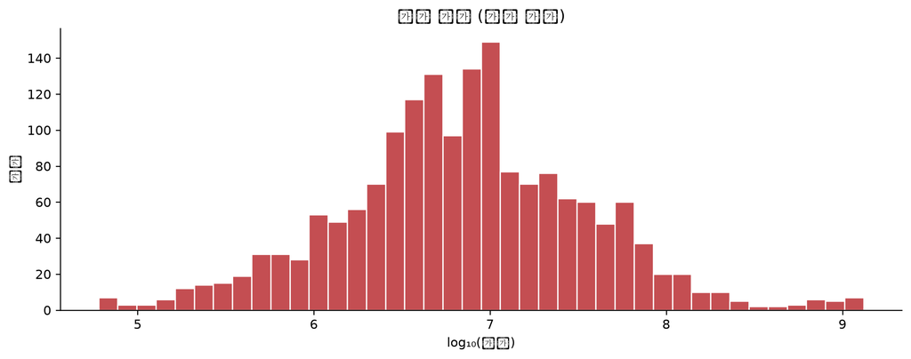

```python
fig, ax = plt.subplots(figsize=(10, 4))
ax.hist(np.log10(df["pop"]), bins=40, color="#C44E52", edgecolor="white")
ax.set_xlabel("log₁₀(인구)")
ax.set_ylabel("빈도")
ax.set_title("인구 분포 (로그 변환)")
plt.tight_layout()
plt.show()
```

## 4 대륙별 비교 분석

### 4.1 대륙별 국가 수

**코드 보기**

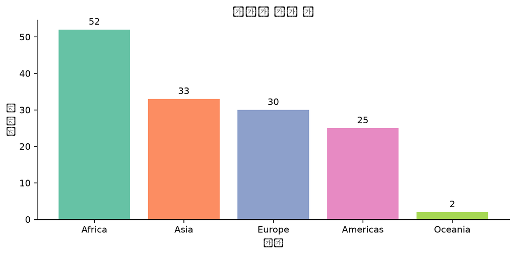

```python
continent_counts = df.groupby("continent")["country"].nunique().sort_values(ascending=False)

fig, ax = plt.subplots(figsize=(8, 4))
bars = ax.bar(continent_counts.index, continent_counts.values, color=sns.color_palette("Set2", 5))
ax.bar_label(bars, padding=3)
ax.set_xlabel("대륙")
ax.set_ylabel("국가 수")
ax.set_title("대륙별 국가 수")
plt.tight_layout()
plt.show()
```

### 4.2 대륙별 평균 지표 (2007년 기준)

2007년 기준 최신 스냅샷으로 대륙 간 격차를 비교합니다. Europe과 Oceania는 높은 기대수명과 GDP를 보이며, Africa는 두 지표 모두 가장 낮은 수준입니다.

**코드 보기**

```python
df_2007 = df[df["year"] == 2007]
summary = df_2007.groupby("continent")[["lifeexp", "gdppercap", "pop"]].mean().round(2)
summary.columns = ["평균 기대수명", "평균 1인당 GDP", "평균 인구"]
summary.sort_values("평균 기대수명", ascending=False)
```

| continent | 평균 기대수명 | 평균 1인당 GDP | 평균 인구 |
| --- | --- | --- | --- |
| Oceania | 80.72 | 29810.19 | 1.227497e+07 |
| Europe | 77.65 | 25054.48 | 1.953662e+07 |
| Americas | 73.61 | 11003.03 | 3.595485e+07 |
| Asia | 70.73 | 12473.03 | 1.155138e+08 |
| Africa | 54.81 | 3089.03 | 1.787576e+07 |

**코드 보기**

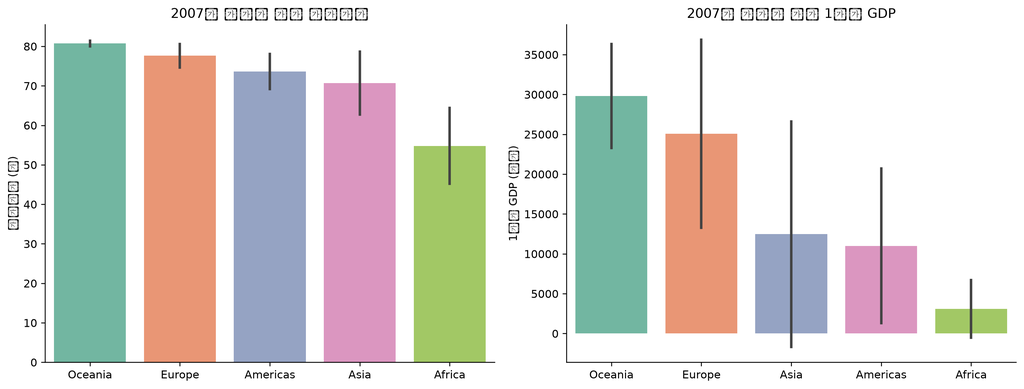

```python
fig, axes = plt.subplots(1, 2, figsize=(13, 5))
palette = sns.color_palette("Set2", 5)

order = summary.sort_values("평균 기대수명", ascending=False).index
sns.barplot(data=df_2007, x="continent", y="lifeexp", order=order,
            palette=palette, ax=axes[0], errorbar="sd")
axes[0].set_title("2007년 대륙별 평균 기대수명")
axes[0].set_xlabel("")
axes[0].set_ylabel("기대수명 (세)")

order2 = summary.sort_values("평균 1인당 GDP", ascending=False).index
sns.barplot(data=df_2007, x="continent", y="gdppercap", order=order2,
            palette=palette, ax=axes[1], errorbar="sd")
axes[1].set_title("2007년 대륙별 평균 1인당 GDP")
axes[1].set_xlabel("")
axes[1].set_ylabel("1인당 GDP (달러)")

plt.tight_layout()
plt.show()
```

## 5 시계열 추세 분석

### 5.1 기대수명 변화 추이

모든 대륙에서 기대수명이 꾸준히 증가하는 추세를 보입니다. Africa는 1990년대 초반 HIV/AIDS 확산의 영향으로 증가세가 둔화되었으며, 이후 회복세를 보입니다.

**코드 보기**

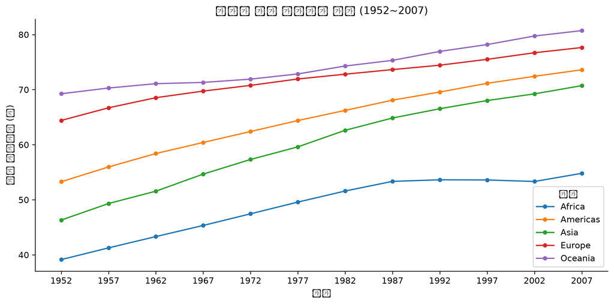

```python
trend = df.groupby(["year", "continent"])["lifeexp"].mean().reset_index()

fig, ax = plt.subplots(figsize=(10, 5))
for continent, group in trend.groupby("continent"):
    ax.plot(group["year"], group["lifeexp"], marker="o", markersize=4, label=continent)

ax.set_xlabel("연도")
ax.set_ylabel("평균 기대수명 (세)")
ax.set_title("대륙별 평균 기대수명 변화 (1952~2007)")
ax.legend(title="대륙")
ax.set_xticks(df["year"].unique())
plt.tight_layout()
plt.show()
```

### 5.2 1인당 GDP 변화 추이

Europe과 Oceania는 안정적인 성장세를 보이며, Asia는 1990년대 이후 급격한 경제 성장을 보입니다. Africa는 전 기간에 걸쳐 낮은 GDP 수준이 유지되고 있습니다.

**코드 보기**

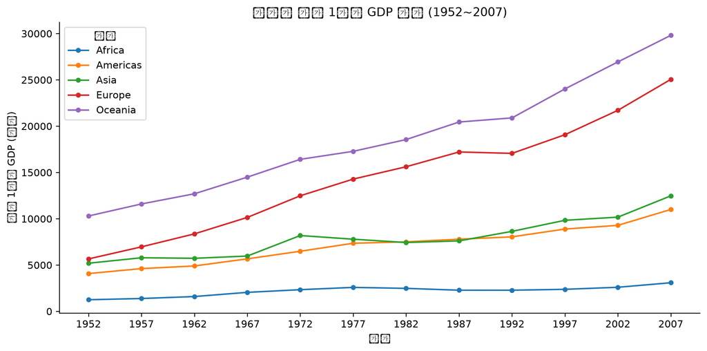

```python
trend_gdp = df.groupby(["year", "continent"])["gdppercap"].mean().reset_index()

fig, ax = plt.subplots(figsize=(10, 5))
for continent, group in trend_gdp.groupby("continent"):
    ax.plot(group["year"], group["gdppercap"], marker="o", markersize=4, label=continent)

ax.set_xlabel("연도")
ax.set_ylabel("평균 1인당 GDP (달러)")
ax.set_title("대륙별 평균 1인당 GDP 변화 (1952~2007)")
ax.legend(title="대륙")
ax.set_xticks(df["year"].unique())
plt.tight_layout()
plt.show()
```

## 6 변수 간 관계 분석

### 6.1 기대수명 vs 1인당 GDP

1인당 GDP와 기대수명은 **양의 상관관계**를 보이며, 로그 스케일에서 선형에 가까운 관계가 나타납니다. 단, GDP가 일정 수준 이상이 되면 기대수명 증가폭이 줄어드는 수확 체감 패턴이 관찰됩니다.

**코드 보기**

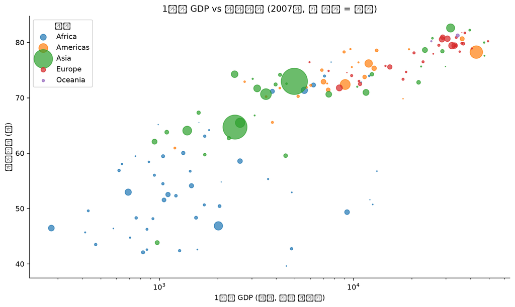

```python
df_2007 = df[df["year"] == 2007].copy()

fig, ax = plt.subplots(figsize=(10, 6))
for continent, group in df_2007.groupby("continent"):
    ax.scatter(group["gdppercap"], group["lifeexp"],
               s=group["pop"] / 1e6, alpha=0.7, label=continent)

ax.set_xscale("log")
ax.set_xlabel("1인당 GDP (달러, 로그 스케일)")
ax.set_ylabel("기대수명 (세)")
ax.set_title("1인당 GDP vs 기대수명 (2007년, 원 크기 = 인구)")
ax.legend(title="대륙")
plt.tight_layout()
plt.show()
```

### 6.2 상관관계 히트맵

**코드 보기**

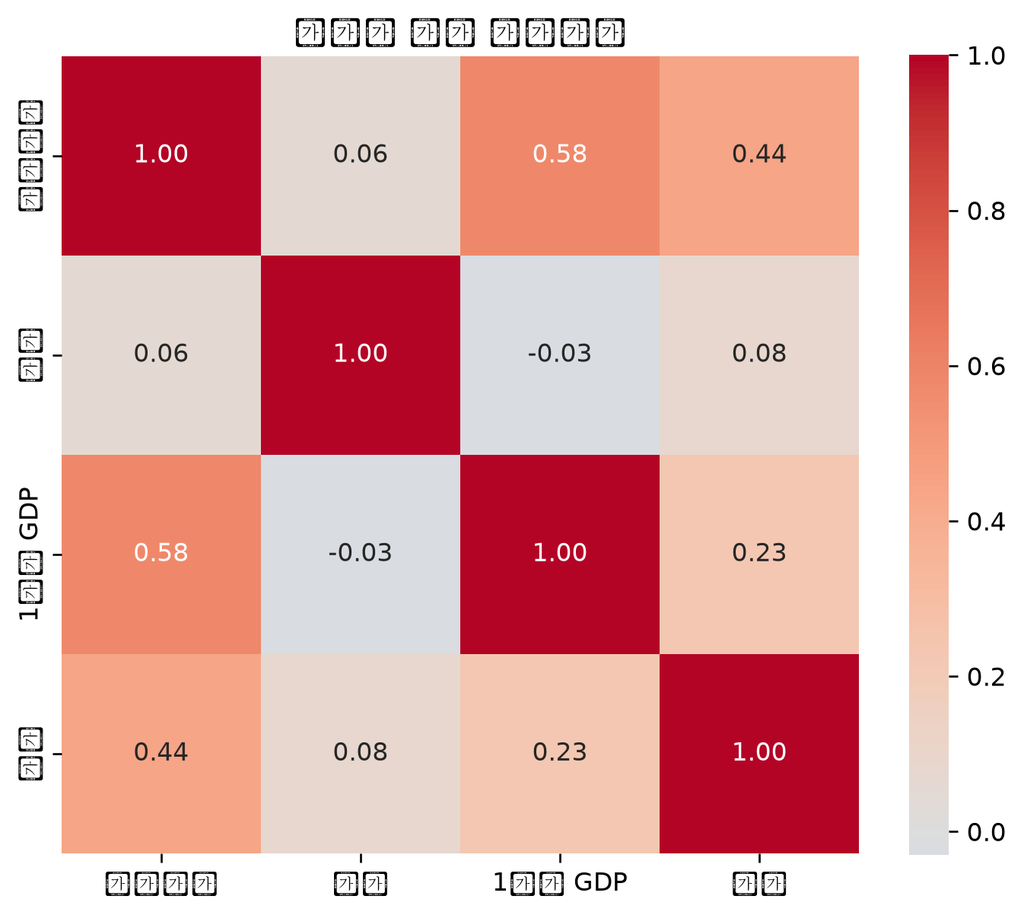

```python
corr = df[["lifeexp", "pop", "gdppercap", "year"]].corr().round(2)

fig, ax = plt.subplots(figsize=(6, 5))
sns.heatmap(corr, annot=True, fmt=".2f", cmap="coolwarm",
            center=0, square=True, ax=ax,
            xticklabels=["기대수명", "인구", "1인당 GDP", "연도"],
            yticklabels=["기대수명", "인구", "1인당 GDP", "연도"])
ax.set_title("수치형 변수 상관관계")
plt.tight_layout()
plt.show()
```

## 7 주요 발견 요약

[output not shown]